# Modeling Response Time: The F > C Phenomenon and the Distance-Difficulty Hypothesis

Authors

Affiliation

Nicole Bonge

University of Arkansas

Ronna C. Turner

University of Arkansas

Presentation Date

April 25, 2025

Abstract

Response time has long been thought to be closely related with intelligence via processing speed. If asked to describe a genius, one might describe a person who can do complex mental calculations quickly and with ease. This stereotype that students with high ability level tend to answer questions fastest has come under question, however, with research indicating that response time is a complex process, dependent on more than just ability level. In this study, we use multilevel linear models to analyze the responses and response times on the 2019 TIMSS mathematics achievement test for eighth-grade students in the United States. Our results demonstrate response time’s dependency on student ability level, whether the student answered the item correctly (F > C phenomenon), and item difficulty in relation to the student’s ability level (distance-difficulty hypothesis). We find evidence to support the F > C phenomenon, the distance-difficulty hypothesis, and an interaction between the two. Our results affirm the complexity of cognitive processes involved in item responses, and challenge the widespread use of response time as a stand-alone metric to assess item quality and respondent effort.

Keywords

Response Time, Item Response Theory, Multilevel Modeling, F > C Phenomenon, Distance-Difficulty Hypothesis

## 1 Introduction

In this study, we extend previous models posed by Tancoš et al. (2023) to achievement data, arguing that response time depends on (1) item difficulty, (2) respondent ability level, (3) the distance between the item’s difficulty and the respondent’s ability level (referred to as the distance-difficulty hypothesis; Thissen, 1983), and (4) whether the respondent answered the item correctly (F > C phenomenon; Beckmann, 2000).

## 2 Theoretical Framework

### 2.1 The F > C Phenomenon

One approach to modelling response time is the F > C (False > Correct) phenomenon (Beckmann, 2000), also called the I > C phenomenon, which posits that respondents take longer to report incorrect answers than they take to provide correct ones. Formally, the F > C phenomenon is given by (Beckmann, 2000, as cited in Tancoš et al., 2023, p. 3):
$$t_{ij} = \mu + \gamma FC_{ij} + \epsilon_{ij}, \tag{1}$$
where $t_{ij}$ is the response time of respondent $j$ on item $i$; $\mu$ is an intercept representing the average response time across all items and respondents; $FC_{ij}$ is a binary indicator representing whether respondent $j$ answered item $i$ correctly; $\gamma$ is an unstandardized regression coefficient representing the mean difference in response time between false and correct answers; and $\epsilon_{ij}$ is a normally distributed residual.

### 2.2 The Distance-Difficulty Hypothesis

Another approach to modeling response time is the distance-difficulty hypothesis, based in item response theory, proposed originally by Thissen (1983). The distance-difficulty hypothesis states that response time decreases with increasing distance between an item’s difficulty ($b_i$) and a respondent’s ability level ($\theta_j$), given by $\delta_{ij} = |\theta_j-b_i|$, called person-item distance. In other words, a respondent should take longer to answer a question that is close to their ability level. Conversely, a respondent should take less time to answer a question that is very easy or very difficult, relative to the respondent’s ability level. Thissen’s model is given by:
$$\ln{(t_{ij})}=\mu+\tau_j+\beta_i-\gamma\delta_{ij}+\epsilon_{ij}, \tag{2}$$
where $\ln{(t_{ij})}$ is a logarithmic transformation of the response time for respondent $j$ on item $i$ (this transformation is meant to achieve normally distributed errors $\epsilon_{ij}$); $\mu$ is the intercept, representing the average response time across all respondents and items; $\tau_j$ represents respondent $j$’s average response time across all items; $\beta_i$ represents the response time of an average-ability respondent for item $i$; and $\gamma$ is a coefficient representing the magnitude of the difference of the relationship between response time and the ability-difficulty distance, which is expected to be negative.

Ferrando and Lorenzo-Seva (2007) proposed an alternative person-item distance measure according to the two-parameter logistic (2PL) model. This model is given by (Ferrando & Lorenzo-Seva, 2007, p. 528):
$$\delta_{ij} = \sqrt{a_i^2 (\theta_j - b_i)^2}, \tag{3}$$
where $a_i$ is the discrimination for item $i$. Well-designed items have positive discrimination, in which case, one can simplify Equation 3 to $\delta_{ij} = a_i|\theta_j-b_i|$. We call this discrimination-adjusted person-item distance the “ability-difficulty distance.”

### 2.3 The Tancoš Models

Combining these approaches, Tancoš et al. (2023) examined the time children took to complete fluid-reasoning tasks in a game-based application, using item difficulty, respondent ability level, and answer correctness as predictors in multilevel regression models with response time as the outcome variable.

Tancoš et al. (2023) proposed two series of multilevel models relating fluid intelligence in children to response time. The first series of models focused on the F > C phenomenon, controlling for item difficulty ($b_i$) and respondent ability ($\theta_j$) with an interaction between answer correctness ($FC_{ij}$) and respondent ability. This series of model culminates with the following model (Tancoš et al., 2023, p. 7):
$$\ln{(t_{ij})} = \mu + \nu_j +\beta_i +\gamma_1FC_{ij}+\gamma_2b_i+\gamma_3\theta_j+\gamma_{13}FC_{ij}\theta_j+\epsilon_{ij}, \tag{4}$$
where $\ln{(t_{ij})}$ is a logarithmic transformation of the response time for person $j$ to item $i$; $\mu$ is the fixed intercept, representing the transformed response time of an average-ability respondent to an item of average difficulty; $\nu_j$ is the random intercept for person $j$, representing the general speediness of respondent $j$ (the average transformed response time of respondent $j$ across all items); $\beta_i$ is the random intercept for item $i$, representing the expected transformed response time required by a respondent of average ability to item $i$; $\gamma_1$, $\gamma_2$, $\gamma_3$, and $\gamma_{13}$ are fixed effects of the corresponding predictors; and $\epsilon_{ij}$ is the normally distributed residual.

The second series of models Tancoš et al. (2023) proposed assessed the distance-difficulty hypothesis, and investigates the incremental validity of the distance-difficulty hypothesis over the F > C phenomenon. This model is given by (Tancoš et al., 2023, p. 8):
$$\ln{(t_{ij})} = \mu + \nu_j +\beta_i +\gamma_4\delta_{ij}+\gamma_1FC_{ij}+\gamma_{14}FC_{ij}\delta_{ij}+\epsilon_{ij}, \tag{5}$$
where $\ln{(t_{ij})}$, $\mu$, $\nu_j$, $\beta_i$, and $FC_{ij}$ are as defined above; $\delta_{ij}=|\theta_j-b_i|$ is the absolute distance between respondent $j$’s ability level and item $i$’s difficulty; $\gamma_1$, $\gamma_2$, $\gamma_3$, and $\gamma_{13}$ are the fixed effects of the corresponding predictors; and $\epsilon_{ij}$ is the normally distributed residual.

In their study, Tancoš et al. (2023) found that the F > C phenomenon remained significant after controlling for item difficulty and person ability, with a significant interaction between ability level and item correctness. Moreover, they found ability level to be a significant predictor of transformed response time (though, only in items with moderate or high difficulty), while item difficulty was not. In sum, their results indicate that on items with moderate-to-high difficulty, children with higher ability levels took longer to report incorrect answers than children with lower ability levels. However, Tancoš et al. (2023) failed to find a relationship between response time and ability level in correctly answered items, challenging the “faster equals smarter” stereotype.

Furthermore, Tancoš et al. (2023) found incremental validity of the distance-difficulty hypothesis above and beyond the F > C phenomenon, providing evidence to support that answer correctness moderates the effect of ability-difficulty distance, ($\delta_{ij}$), on response time. Taken together, these results suggest that items near a respondent’s ability level take the longest amount of time to answer, with even more time required to answer items incorrectly. Moreover, as $\delta_{ij}$ increased the difference in response time narrowed, eventually changing direction. That is, when an item was very easy or very difficult relative to the respondent’s ability level, respondents tended to take longer to report correct answers than false ones.

### 2.4 The Proposed Models

In this study, we will extend the Tancoš et al. (2023) methodology to mathematics achievement data from the 2019 TIMSS (Trends in International Mathematics and Science Study) for fourth- and eighth-grade students. Using these data, we will compare results from two series of multilevel linear models to assess the F > C phenomenon, the distance-difficulty hypothesis, and any interaction between the two.

The first series of models will assess the F > C phenomenon, controlling for ability level and item difficulty. With these models, we will determine whether the relationship between ability level and response time is moderated by answer correctness. Then, we will assess the distance-difficulty hypothesis using the second series of models, controlling for the discrimination-adjusted ability-difficulty distance. If we find the F > C phenomenon and distance-difficulty hypothesis both hold, we will investigate whether there is a significant interaction between the (discrimination-adjusted) ability-difficulty distance, which we call “the Tancoš model.” A significant interaction would suggest a difference in the relationship between the time needed to answer an item and the ability-difficulty distance, according to whether the respondent answered the item correctly. See Appendix 1 for the list of models used.

## 3 Method

### 3.1 Participants and Measures

We examined data from the 2019 TIMSS mathematics achievement assessment. The TIMSS is a set of international assessments of fourth- and eighth-grade students’ mathematics and science achievement and attitudes, along with survey responses from teachers and principals to gather information related to the background contexts for learning. The TIMSS is conducted every four years, with 64 countries participating in the 2019 assessment cycle (Mullis et al., 2020). In the United States, data were collected from 9,944 eighth-grade students in 273 schools. Beginning in 2019, the United States opted into the eTIMSS, a new computer-based version of the assessment, allowing response time data to be collected alongside participating student responses. Students answered items from one of fourteen booklets, composed of item block combinations. Response times were computed as time in seconds spent on a page with a single item, or a set of connected items (such as multi-part questions); to maximize the validity of our response time records, we dropped items that were presented as a set on a page and kept only those items that were presented in isolation on a page. We call these “isolated items.” After dropping items presented together on a page, we analyzed responses from each booklet to determine which booklet(s) had the most isolated items and the most responses per booklet. A list of each booklet’s number of isolated items and number of respondents for eighth grade students are shown in Appendix 2. Of the 14 booklets, we chose Booklet 14. Our final sample contained 552 complete responses to 13 isolated items.

### 3.2 IRT Analysis

All analyses were conducted using R Statistical Software (v4.4.1; R Core Team, 2024). The TIMSS mathematics assessments were validated by the creators using a two-parameter logistic (2PL) model, so we performed a 2PL IRT analysis using the *mirt* R package (v1.41; Chalmers, 2012) to obtain each item’s difficulty ($b_i$), discrimination ($a_i$), and each respondent’s estimated ability parameter ($θ_j$). See Table 1 for descriptive statistics and 2PL parameters. Empirical reliability was sufficiently high for analysis ($r_{xx} = .85$).

### 3.3 Main Analysis

Our main analysis involved two series of nested linear multilevel regression models. The first series of models tested the F > C phenomenon, controlling for item difficulty and respondent ability; the second series of models assessed the distance-difficulty hypothesis and its interaction with the F > C phenomenon. We used the *lme4* package (v1.1-35.5; Bates et al., 2015) to estimate each model, and after estimation, we computed the variance inflation factor (VIF) to check each model for multicollinearity using the *car* package (v3.1-3; Fox & Weisberg, 2019). Finally, we used the *lmerTest* package (v3.1-3; Kuznetsova et al., 2017) to compare models.

We began our analysis by estimating a null model (Model 0) to serve as a baseline for both series of models. Consistent with Tancoš et al. (2023), Model 0 included only fixed and random intercept terms for respondents and items; all models used a logarithmically transformed response time for the dependent variable to linearize the relationship between the predictor variables and response time.

For the first series of models, we began by defining Model A1, which includes only a binary predictor for item correctness ($FC_{ij}$); Model A2 includes two additional predictors, item difficulty $b_i$ and respondent ability $\theta_j$ for control variables; finally, Model A3 includes an interaction term between item correctness and respondent ability to investigate whether item correctness moderates the relationship between ability level and the F > C phenomenon. Model A3 is given by Equation 4.

The second series of models begins with Model B1, which includes only the discrimination-adjusted ability-difficulty distance, $\delta_{ij}=a_i |\theta_j-b_i|$ (“ability-difficulty distance”) to test the distance-difficulty hypothesis. Model B2 includes $FC_{ij}$, representing item correctness, to assess the incremental validity of the F > C phenomenon beyond the distance-difficulty hypothesis. Finally, Model B3, given by Equation 5, includes an interaction term between the ability-difficulty distance $\delta_{ij}$ and item correctness $FC_{ij}$ to investigate whether the distance-difficulty hypothesis is moderated by item correctness.

## 4 Results

### 4.2 Models Assessing F > C Phenomenon

In Model A3, the F > C phenomenon remained significant ($γ_1=$ 0.19, 95% CI [0.15, 0.23]), as did item difficulty ($γ_2=$ 0.35, 95% CI [0.07, 0.62]) and student ability level ($γ_3=$ 0.22, 95% CI [0.18, 0.27]). Moreover, we found a significant interaction between item correctness and ability level ($γ_{13}=$-0.21, 95% CI [-0.26, -0.16]). Taken together, we can interpret this to mean that students with lower ability levels took longer to answer items correctly than incorrectly, and students with higher ability levels took longer to provide incorrect answers than correct ones. Moreover, we found a positive relationship between ability level and response time for incorrect answers, but no substantial relationship between ability level and response time for correct answers. This pattern is shown in Figure 1, and Table 5 displays complete results for Model A3.

Overall, every model fit better than the null model, and each model fit better than the preceding model in the series Table 6. Given the information criteria and the goodness-of-fit measures, we chose to retain Model A3 as our final model.

### 4.3 Models Assessing the Distance-Difficulty Hypothesis

Model B1 assessed the distance-difficulty hypothesis as a predictor for the logarithmic transform of response time, which was significant ($γ_4=$ -0.09, 95% CI [-0.10, -0.08]). From this, we see that for each one-unit increase in $δ_{ij}$, response time is decreased by 8.6%. For example, when $δ_{ij}=0$, the expected response time is 60.46 seconds; when $δ_{ij}=1$, the expected response time is 55.26 seconds; when $δ_{ij}=2$, the expected response time is 50.50 seconds, and so on. Table 7 displays the complete results for Model B1.

For Model B2, we added item correctness as a fixed effect, which was significant ($γ_1=$ 0.22, 95% CI [0.18, 0.26]). The ability-difficulty distance remained significant but was suppressed ($γ_4=$ -0.09, 95% CI [-0.11, -0.08]). From this, we see that students took longer to provide correct answers than incorrect ones, and regardless of item correctness, as the ability-difficulty distance increased, response time decreased. See Table 8 for complete results for Model B2.

Overall, each model fit the data better than the null model, and every model in the series fit the data better than the preceding model (Table 10). Per this evidence, along with information criteria for each model, we chose to retain Model B3 as our final model.

## 5 Conclusion

The results of our study show that eighth-grade students’ responses to a mathematics achievement assessment support the F > C phenomenon after controlling for ability level, item difficulty, and item correctness. Moreover, students’ responses provide evidence to support the distance-difficulty hypothesis after controlling for ability-difficulty distance and item correctness, with a significant interaction between item correctness and the ability-difficulty distance.

The interaction between the F > C phenomenon and item correctness may have several explanations. Students with higher ability levels may have higher levels of grit and may be more likely to try multiple approaches to a problem if their initial strategy/approach does not yield a solution (Credé et al., 2017; Duckworth et al., 2007; Steinmayr et al., 2018). In contrast, students with lower ability levels may not see a clear path to a solution when beginning a problem. As we saw, lower-ability students took longer to answer questions correctly, which could be indicative of students pausing to develop a plan of attack before answering the question. Researchers (e.g., Chan et al., 2022) have found that longer pauses before beginning a problem can lead to more efficient problem-solving, and, ultimately, faster response times.

The observed patterns in the relationship between the ability-difficulty distance and response time align with the findings from the Tancoš et al. (2023) study; students took longest to answer questions that matched the student’s ability level, and response time decreased as the ability-difficulty distance increased. One possible explanation for the extended time taken to answer questions that match a student’s ability level is that the question may be difficult enough to be challenging, but not so challenging that they have little chance of answering the question correctly. When items are very easy relative to a student’s ability level, this pattern seems intuitive: easier items take less time. However, the idea that students take less time to answer very difficult questions is less intuitive but may be a result of an initial misjudgment of the item’s difficulty, which would explain our finding that students took longer to answer very difficult questions incorrectly.

Our study is limited by the low-stakes nature of the TIMSS mathematics assessments. Students may not have been highly motivated to perform well in this achievement assessment, particularly toward the end of the test, so our estimates of student ability and item difficulty may be biased by a lack of sufficient effort. Moreover, the magnitude of errors may be compounded by the initial IRT estimate and subsequent multilevel regression model. Finally, there may be unanalyzed differences in the observed relationships across students of different demographic groups (such as gender, race/ethnicity, or socio-economic status). Future research could examine the magnitude of the fixed effects we analyzed in this study by demographic group. Future research may also explore whether the results from this study hold with attitudinal scales or achievement scales in other academic disciplines. This study extended the response time models found by Tancoš et al. (2023) in a fluid-reasoning task to a mathematics achievement assessment involving crystallized intelligence. Researchers and educators alike utilize response time as a catch-all measurement of item suitability, respondent effort, and ability-level, but this study’s results imply response time is not appropriate as a stand-alone diagnostic tool, as response time is influenced by a variety of factors.

## References

Bassili, J. N., & Scott, B. S. (1996). Response latency as a signal to question problems in survey research. *Public Opinion Quarterly*, *60*, 390–399. https://academic.oup.com/poq/article/60/3/390/1832313

Bates, D., Mächler, M., Bolker, B., & Walker, S. (2015). Fitting linear mixed-effects models using lme4. *Journal of Statistical Software*, *67*, 1–48. https://doi.org/10.18637/jss.v067.i01

Beckmann, J. F. (2000). Differentielle latenzzeitefekte bei der bearbeitung von reasoning-items. *Diagnostica*, *46*, 124–129.

Boeck, P. D., & Jeon, M. (2019). An overview of models for response times and processes in cognitive tests. *Frontiers in Psychology*, *10*. https://doi.org/10.3389/fpsyg.2019.00102

Bowling, N. A., Huang, J. L., Brower, C. K., & Bragg, C. B. (2023). The quick and the careless: The construct validity of page time as a measure of insufficient effort responding to surveys. *Organizational Research Methods*, *26*, 323–352. https://doi.org/10.1177/10944281211056520

Chalmers, R. P. (2012). Mirt: A multidimensional item response theory package for the r environment. *Journal of Statistical Software*, *48*, 1–29. https://doi.org/10.18637/jss.v048.i06

Chan, J. Y. C., Ottmar, E. R., & Lee, J. E. (2022). Slow down to speed up: Longer pause time before solving problems relates to higher strategy efficiency. *Learning and Individual Differences*, *93*. https://doi.org/10.1016/j.lindif.2021.102109

Credé, M., Tynan, M. C., & Harms, P. D. (2017). Much ado about grit: A meta-analytic synthesis of the grit literature. *Journal of Personality and Social Psychology*, *113*, 492–511. https://doi.org/10.1037/pspp0000102

Duckworth, A. L., Peterson, C., Matthews, M. D., & Kelly, D. R. (2007). Grit: Perseverance and passion for long-term goals. *Journal of Personality and Social Psychology*, *92*, 1087–1101. https://doi.org/10.1037/0022-3514.92.6.1087

Ferrando, P. J., & Lorenzo-Seva, U. (2007). A measurement model for likert responses that incorporates response time. *Multivariate Behavioral Research*, *42*, 675–706. https://doi.org/10.1080/00273170701710247

Fox, J., & Weisberg, S. (2019). *An r companion to applied regression* (Third). Sage.

Gernsbacher, M. A., Soicher, R. N., & Becker-Blease, K. A. (2020). Four empirically based reasons not to administer time-limited tests. *Translational Issues in Psychological Science*, *6*, 175–190. https://doi.org/10.1037/tps0000232

Höhne, J. K., Schlosser, S., & Krebs, D. (2017). Investigating cognitive effort and response quality of question formats in web surveys using paradata. *Field Methods*, *29*, 365–382. https://doi.org/10.1177/1525822X17710640

Krosnick, J. A. (1991). Response strategies for coping with the cognitive demands of attitude measures in surveys. *Applied Cognitive Psychology*, *5*, 213–236. https://doi.org/10.1002/acp.2350050305

Kuznetsova, A., Brockhoff, P. B., & Christensen, R. H. B. (2017). lmerTest package: Tests in linear mixed effects models. *Journal of Statistical Software*, *82*, 1–26. https://doi.org/10.18637/jss.v082.i13

Lenzner, T. (2012). Effects of survey question comprehensibility on response quality. *Field Methods*, *24*, 409–428. https://doi.org/10.1177/1525822X12448166

Lenzner, T., Kaczmirek, L., & Lenzner, A. (2010). Cognitive burden of survey questions and response times: A psycholinguistic experiment. *Applied Cognitive Psychology*, *24*, 1003–1020. https://doi.org/10.1002/acp.1602

Mullis, I. V. S., Martin, M. O., Foy, P., Kelly, D. L., & Fishbein, B. (2020). TIMSS 2019 international results in mathematics and science. In *Boston College, TIMSS & PIRLS International Study Center website*. https://timssandpirls.bc.edu/timss2019/international-results/

Nagy, G., & Ulitzsch, E. (2022). A multilevel mixture IRT framework for modeling response times as predictors or indicators of response engagement in IRT models. *Educational and Psychological Measurement*, *82*, 845–879. https://doi.org/10.1177/00131644211045351

Nguyen, H. L. T. (2017). *Tired of survey fatigue? Insufficient effort responding due to survey fatigue* [PhD thesis]. Middle Tennessee State University.

Steinmayr, R., Weidinger, A. F., & Wigfield, A. (2018). Does students’ grit predict their school achievement above and beyond their personality, motivation, and engagement? *Contemporary Educational Psychology*, *53*, 106–122. https://doi.org/10.1016/j.cedpsych.2018.02.004

Tancoš, M., Chvojka, E., Jabůrek, M., & Portešová, Š. (2023). Faster ≠ smarter: Children with higher levels of ability take longer to give incorrect answers, especially when the task matches their ability. *Journal of Intelligence*, *11*. https://doi.org/10.3390/jintelligence11040063

Team, R. C. (2019). *R: A language and environment for statistical computing*. R Foundation for Statistical Computing. http://www.R-project.org/

Thissen, D. (1983). Timed testing- an approach using item response theory. In *New horizons in testing: Latent trait test theory and computerized adaptive testing* (pp. 179–203).

Ulitzsch, E., Pohl, S., Khorramdel, L., Kroehne, U., & Davier, M. von. (2022). A response-time-based latent response mixture model for identifying and modeling careless and insufficient effort responding in survey data. *Psychometrika*, *87*, 593–619. https://doi.org/10.1007/s11336-021-09817-7

Wise, S. L., & Demars, C. E. (2006). An application of item response time: The effort-moderated IRT model national council on measurement in education. In *Source: Journal of Educational Measurement* (Vol. 43, pp. 19–38). https://www.jstor.org/stable/20461807

## Tables

Table 1. Descriptive Statistics

| Item | Sample | Item Difficulty | Item Discrimination | Response (Proportion Correct) M | Response (Proportion Correct) SD | Response Time (Seconds) M | Response Time (Seconds) SD |
| --- | --- | --- | --- | --- | --- | --- | --- |
| 1 | 552 | -0.13 | 1.01 | 0.53 | 0.50 | 40.90 | 47.73 |
| 2 | 552 | 0.00 | 1.75 | 0.50 | 0.50 | 72.68 | 58.69 |
| 3 | 552 | 0.34 | 1.67 | 0.41 | 0.49 | 56.62 | 59.44 |
| 4 | 552 | -0.84 | 2.09 | 0.74 | 0.44 | 34.77 | 29.84 |
| 5 | 552 | -0.38 | 2.41 | 0.62 | 0.49 | 70.38 | 81.01 |
| 6 | 552 | -0.16 | 2.57 | 0.55 | 0.50 | 102.51 | 61.66 |
| 7 | 552 | 0.08 | 1.93 | 0.48 | 0.50 | 55.06 | 47.03 |
| 8 | 552 | 1.51 | 2.21 | 0.12 | 0.32 | 78.65 | 62.14 |
| 9 | 552 | 1.57 | 2.85 | 0.09 | 0.29 | 115.56 | 80.58 |
| 10 | 552 | 1.05 | 2.54 | 0.20 | 0.40 | 58.11 | 39.61 |
| 11 | 552 | -0.61 | 1.31 | 0.65 | 0.48 | 67.59 | 43.22 |
| 12 | 552 | -0.77 | 1.23 | 0.68 | 0.47 | 40.25 | 31.85 |
| 13 | 552 | 0.65 | 1.74 | 0.32 | 0.47 | 143.72 | 101.17 |

Table 2. Parameters for Model 0

|  | Coef. | Est. |  | 95% CI LL | 95% CI UL |
| --- | --- | --- | --- | --- | --- |
| *Fixed Effects* |  |  |  |  |  |
| Intercept | μ | 3.92 | *** | 3.67 | 4.18 |
| *Random Effects* |  |  |  |  |  |
| Person intercept variance | var(*ν<sub>j</sub>* ) | 0.18 | *** |  |  |
| Item intercept variance | var(*β<sub>i</sub>* ) | 0.20 | *** |  |  |
| Residual Variance | var(*ε<sub>ij</sub>* ) | 0.41 |  |  |  |

*Note.* Coef – coefficient; Est – estimate; CI – confidence interval; LL – lower limit; UL – upper limit; Var – variance. * p < .05, ** p < .01, *** p < .001.

Table 3. Parameters for Model A1

|  | Coef. | Est. |  | 95% CI LL | 95% CI UL |
| --- | --- | --- | --- | --- | --- |
| *Fixed Effects* |  |  |  |  |  |
| Intercept | μ | 3.83 | *** | 3.56 | 4.10 |
| Correct Answer (FC) | γ<sub>1</sub> | 0.21 | *** | 0.17 | 0.25 |
| *Random Effects* |  |  |  |  |  |
| Person intercept variance | var(*ν<sub>j</sub>* ) | 0.17 | *** |  |  |
| Item intercept variance | var(*β<sub>i</sub>* ) | 0.22 | *** |  |  |
| Residual Variance | var(*ε<sub>ij</sub>* ) | 0.41 |  |  |  |

*Note.* Coef – coefficient; Est – estimate; CI – confidence interval; LL – lower limit; UL – upper limit; Var – variance. * p < .05, ** p < .01, *** p < .001.

Table 4. Parameters for Model A2

|  | Coef. | Est. |  | 95% CI LL | 95% CI UL |
| --- | --- | --- | --- | --- | --- |
| *Fixed Effects* |  |  |  |  |  |
| Intercept | μ | 3.78 | *** | 3.56 | 4.00 |
| Correct Answer (FC) | γ<sub>1</sub> | 0.18 | *** | 0.14 | 0.22 |
| Item Difficulty | γ<sub>2</sub> | 0.35 | *** | 0.08 | 0.62 |
| Person Ability | γ<sub>3</sub> | 0.13 | *** | 0.09 | 0.17 |
| *Random Effects* |  |  |  |  |  |
| Person intercept variance | var(*ν<sub>j</sub>* ) | 0.16 | *** |  |  |
| Item intercept variance | var(*β<sub>i</sub>* ) | 0.15 | *** |  |  |
| Residual Variance | var(*ε<sub>ij</sub>* ) | 0.41 |  |  |  |

*Note.* Coef – coefficient; Est – estimate; CI – confidence interval; LL – lower limit; UL – upper limit; Var – variance. * p < .05, ** p < .01, *** p < .001.

Table 5. Parameters for Model A3

|  | Coef. | Est. |  | 95% CI LL | 95% CI UL |
| --- | --- | --- | --- | --- | --- |
| *Fixed Effects* |  |  |  |  |  |
| Intercept | μ | 3.83 | *** | 3.60 | 4.05 |
| Correct Answer (FC) | γ<sub>1</sub> | 0.19 | *** | 0.15 | 0.23 |
| Item Difficulty | γ<sub>2</sub> | 0.35 | *** | 0.07 | 0.62 |
| Person Ability | γ<sub>3</sub> | 0.22 | *** | 0.18 | 0.27 |
| FC x Ability | γ<sub>13</sub> | -0.21 | *** | -0.26 | -0.16 |
| *Random Effects* |  |  |  |  |  |
| Person intercept variance | var(*ν<sub>j</sub>* ) | 0.15 | *** |  |  |
| Item intercept variance | var(*β<sub>i</sub>* ) | 0.16 | *** |  |  |
| Residual Variance | var(*ε<sub>ij</sub>* ) | 0.40 |  |  |  |

*Note.* Coef – coefficient; Est – estimate; CI – confidence interval; LL – lower limit; UL – upper limit; Var – variance. * p < .05, ** p < .01, *** p < .001.

Table 6. Model Fit For Series 1 Models

[output not shown]

Table 7. Parameters for Model B1

|  | Coef. | Est. |  | 95% CI LL | 95% CI UL |
| --- | --- | --- | --- | --- | --- |
| *Fixed Effects* |  |  |  |  |  |
| Intercept | μ | 4.10 | *** | 3.82 | 4.39 |
| Ability-Diffiulty Distance | γ<sub>4</sub> | -0.09 | *** | -0.10 | -0.08 |
| *Random Effects* |  |  |  |  |  |
| Person intercept variance | var(*ν<sub>j</sub>* ) | 0.17 | *** |  |  |
| Item intercept variance | var(*β<sub>i</sub>* ) | 0.24 | *** |  |  |
| Residual Variance | var(*ε<sub>ij</sub>* ) | 0.40 |  |  |  |

*Note.* Coef – coefficient; Est – estimate; CI – confidence interval; LL – lower limit; UL – upper limit; Var – variance. * p < .05, ** p < .01, *** p < .001.

Table 8. Parameters for Model B2

|  | Coef. | Est. |  | 95% CI LL | 95% CI UL |
| --- | --- | --- | --- | --- | --- |
| *Fixed Effects* |  |  |  |  |  |
| Intercept | μ | 4.01 | *** | 3.71 | 4.31 |
| Correct Answer (FC) | γ<sub>1</sub> | 0.22 | *** | 0.18 | 0.26 |
| Ability-Diffiulty Distance | γ<sub>4</sub> | -0.09 | *** | -0.11 | -0.08 |
| *Random Effects* |  |  |  |  |  |
| Person intercept variance | var(*ν<sub>j</sub>* ) | 0.16 | *** |  |  |
| Item intercept variance | var(*β<sub>i</sub>* ) | 0.28 | *** |  |  |
| Residual Variance | var(*ε<sub>ij</sub>* ) | 0.40 |  |  |  |

*Note.* Coef – coefficient; Est – estimate; CI – confidence interval; LL – lower limit; UL – upper limit; Var – variance. * p < .05, ** p < .01, *** p < .001.

Table 9. Parameters for Model B3

|  | Coef. | Est. |  | 95% CI LL | 95% CI UL |
| --- | --- | --- | --- | --- | --- |
| *Fixed Effects* |  |  |  |  |  |
| Intercept | μ | 3.98 | *** | 3.69 | 4.27 |
| Correct Answer (FC) | γ<sub>1</sub> | 0.29 | *** | 0.24 | 0.34 |
| Ability-Diffiulty Distance | γ<sub>4</sub> | -0.07 | *** | -0.08 | -0.05 |
| FC x Distance | γ<sub>14</sub> | -0.08/td> | *** | -0.11 | -0.05 |
| *Random Effects* |  |  |  |  |  |
| Person intercept variance | var(*ν<sub>j</sub>* ) | 0.17 | *** |  |  |
| Item intercept variance | var(*β<sub>i</sub>* ) | 0.26 | *** |  |  |
| Residual Variance | var(*ε<sub>ij</sub>* ) | 0.39 |  |  |  |

*Note.* Coef – coefficient; Est – estimate; CI – confidence interval; LL – lower limit; UL – upper limit; Var – variance. * p < .05, ** p < .01, *** p < .001.

Table 10. Model Fit For Series 2 Models

|  | Model 0 | Model B1 | Model B2 | Model B3 |
| --- | --- | --- | --- | --- |
| Conditional *R<sup>2</sup>* | .48 | .53 | .55 | .54 |
| Marginal *R<sup>2</sup>* | .00 | .03 | .05 | .04 |
| Log-likelihood | -7,558.04 | -7,450.04 | -7,385.87 | -7,374.85 |
| AIC | 15,124.07 | 14,910.08 | 14,783.73 | 14,763.69 |
| BIC | 15,151.58 | 14,944.47 | 14,825.00 | 14,811.84 |
| Δχ<sup>2</sup>(df) |  | 215.992(1)*** | 128.346(1)*** | 22.041(1)*** |

## Figures

Figure 1. From Model A3, students’ predicted response time according to ability level and whether the student answered the question correctly.

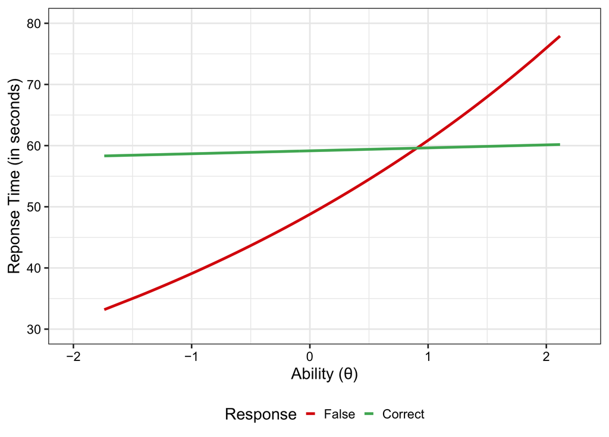

Figure 2. From Model B3, students’ predicted response time according to the discrimination-adjusted ability-difficulty distance and whether the student answered the question correctly.

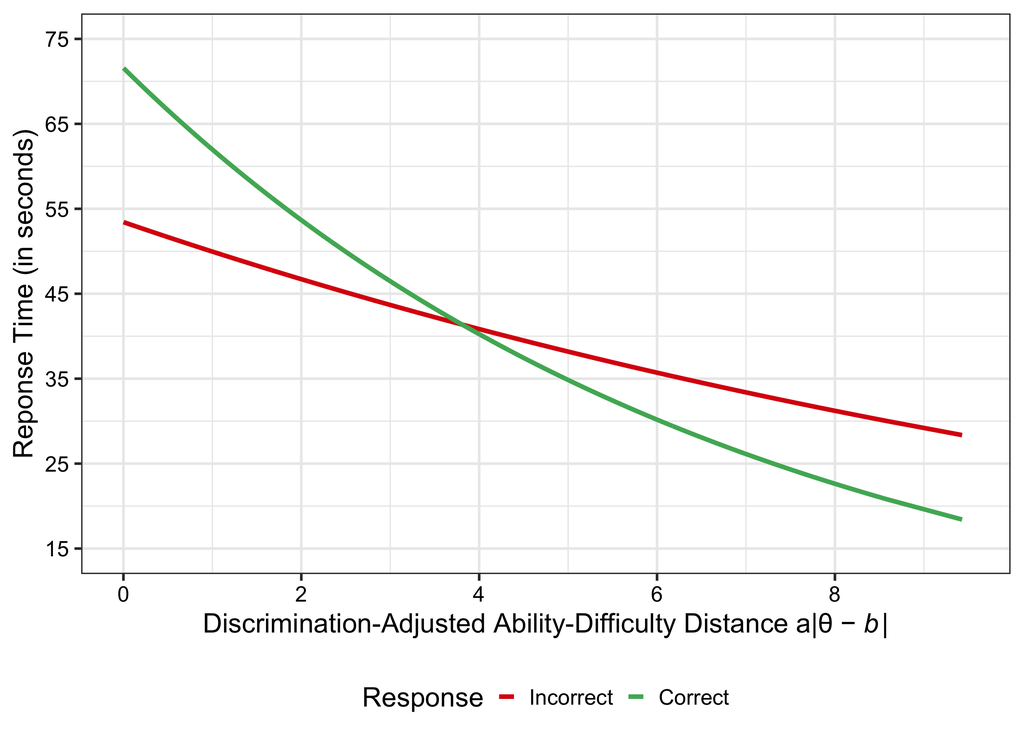

## Appendix

### Appendix 1. List of Models Used

Null Model (Model 0):

$$\ln{(t_{ij})} = \mu + \nu_j + \beta_i + \epsilon_{ij}$$

Model A1:

$$\ln{(t_{ij})} = \mu + \nu_j + \beta_i + \gamma_1 FC_{ij} + \epsilon_{ij}$$

Model A2:

$$\ln{(t_{ij})} = \mu + \nu_j + \beta_i + \gamma_1 FC_{ij} + \gamma_2b_i + \gamma_3 \theta_j + \epsilon_{ij}$$

Model A3:

$$\ln{(t_{ij})} = \mu + \nu_j + \beta_i + \gamma_1 FC_{ij} + \gamma_2b_i + \gamma_3 \theta_j + \gamma_{13} FC_{ij} \theta_j+ \epsilon_{ij}$$

Model B1:

$$\begin{align}
\ln{(t_{ij})} &= \mu + \nu_j + \beta_i + \gamma_4 a_i |\theta_j - b_i|+ \epsilon_{ij} \\
&=\mu + \nu_j +\beta_i +\gamma_4\delta_{ij}+\epsilon_{ij}
\end{align}$$

Model B2:

$$\begin{align}
\ln{(t_{ij})} &= \mu + \nu_j + \beta_i + \gamma_4 a_i |\theta_j - b_i|+ \gamma_1FC_{ij}+\epsilon_{ij} \\
&=\mu + \nu_j +\beta_i +\gamma_4\delta_{ij}+\gamma_1 FC_{ij}+\epsilon_{ij}
\end{align}$$

Model B3:

$$\begin{align}
\ln{(t_{ij})} &= \mu + \nu_j + \beta_i + \gamma_4 a_i |\theta_j - b_i|+ \gamma_1FC_{ij}+\gamma_{14}FC_{ij}a_i|\theta_j-b_i|+\epsilon_{ij} \\
&=\mu + \nu_j +\beta_i +\gamma_4\delta_{ij}+\gamma_1 FC_{ij}+\gamma_{14}FC_{ij}\delta_{ij}+\epsilon_{ij}
\end{align}$$

### Appendix 2. Booklet Overview for 2019 TIMSS Mathematics Achievement Assessment

| Booklet Number | Isolated Items | Sample Size |
| --- | --- | --- |
| 1 | 10 | 624 |
| 2 | 12 | 621 |
| 3 | 12 | 626 |
| 4 | 5 | 606 |
| 5 | 12 | 619 |
| 6 | 11 | 633 |
| 7 | 12 | 623 |
| 8 | 8 | 617 |
| 9 | 11 | 606 |
| 10 | 13 | 619 |
| 11 | 13 | 620 |
| 12 | 11 | 625 |
| 13 | 10 | 637 |
| 14 | 13 | 622 |

*Note.* Isolated items refer to items that are shown on a webpage as a stand-alone item. Adapted from Trends in International Mathematics and Science Study – TIMSS 2019. Copyright 2021 by International Association for the Evaluation of Education Achievement (IEA). Publisher: TIMSS & PIRLS International Study Center, Lynch School of Education and Human Development, Boston College.